# eDNA visual–joint model: v3.2 — a debugging case study

Eight PRs of iterative diagnosis on the HSGP latent-field fit

Author

MMARINeDNA / eDNAVisualJointModel

Published

April 28, 2026

# 1 Background

v3 of the pipeline (see the v3 notebook) fit a 3-D anisotropic HSGP joint model for three species (Pacific hake, humpback whale, and Pacific white-sided dolphin) with combined qPCR + metabarcoding observations. The first v3 fits showed severe sampler pathology: every iteration was hitting max-treedepth, the energy diagnostic was failing, $\hat R$ on `mu_sp` / `gp_sigma` / `gp_l` was 2–3, and spatial recovery was nearly flat ($R^2 \approx 0.02$ on `log λ`). v3.1 attempted a single-shot reparameterisation (tighter priors, reduced HSGP basis) and *also* failed.

**v3.2 is a deliberately stripped-down debug version**: one species (hake), one sample depth (surface), one observation type (qPCR). The point was to isolate the HSGP machinery from the metabarcoding likelihood so we could find which pieces of the model were mis-configured and fix them one at a time.

This notebook documents what we found, in the order we found it — eight PRs of iterative diagnosis (PRs [#22](https://github.com/MMARINeDNA/eDNAVisualJointModel/pull/22), [#23](https://github.com/MMARINeDNA/eDNAVisualJointModel/pull/23), [#25](https://github.com/MMARINeDNA/eDNAVisualJointModel/pull/25), [#26](https://github.com/MMARINeDNA/eDNAVisualJointModel/pull/26), [#27](https://github.com/MMARINeDNA/eDNAVisualJointModel/pull/27), [#28](https://github.com/MMARINeDNA/eDNAVisualJointModel/pull/28), [#29](https://github.com/MMARINeDNA/eDNAVisualJointModel/pull/29), [#30](https://github.com/MMARINeDNA/eDNAVisualJointModel/pull/30)). Each PR’s diagnostic signal pointed at the next bug. Each fix was done in isolation so we could attribute changes cleanly.

# 2 The simplification

**Note**

The same domain and bathymetry as v3 (UTM Zone 10N, San Francisco to ~49°N, rotated cross-shore coordinate). The core simplifications:

- **Hake only**: $S = 1$. Humpback and PWSD removed.
- **Surface only**: $Z_{\text{sample}} = 0$ for every sample. The water-column eDNA multiplier collapses to 1, so `log_zsample_effect` is all zeros and contributes nothing.
- **qPCR only**: the metabarcoding ZI-Beta-Binomial likelihood and every parameter that was MB-only (`beta0_phi`, `gamma0_phi`, `gamma1_phi`) are removed from the Stan model.

After all the fixes documented below, the simulation also matches the model’s structural assumption exactly (Option A — see §4.4): $f_s$ is a pure zero-mean GP with covariance $K(\ell_x, \ell_y, \ell_z)$, no deterministic habitat preference function added.

## 2.1 Simulated truth

Per-species true parameters used by the v3.2 sim. With S=1 there’s just one row.

|  | Species | mu_s (log animals/km^2) | mean lambda (animals/km^2) | gp_sigma | lx (km) | ly (km) | lz (m) |
| --- | --- | --- | --- | --- | --- | --- | --- |
| hake | Pacific hake | 2.996 | 44.614 | 1.2 | 50 | 300 | 150 |

`simulated_edna_fields_v3.2.pdf` shows the simulated truth at station locations. With Option A in place there’s no closed-form expected $\lambda$ surface to plot — the field is just a single GP draw.

### 2.1.1 Page 1 — Surface stations coloured by `log(λ)`

300 stations on the X–Y plane, coloured by their simulated `log(lambda)`. Grey contours = 200 m and 1000 m isobaths. The smooth patches reflect the kernel’s length-scales (`lx = 50 km`, `ly = 300 km`, `lz = 150 m`).

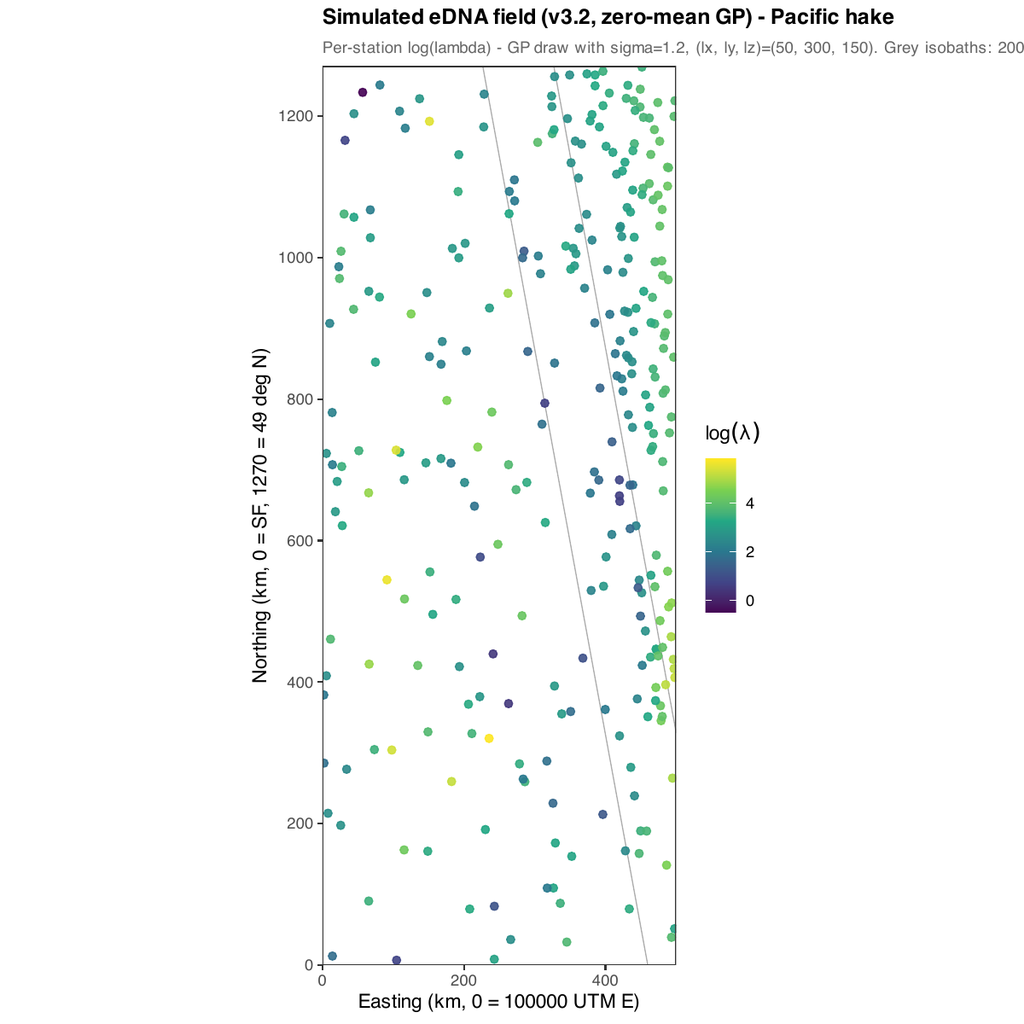

Simulated `log(λ)` at surface stations.

### 2.1.2 Page 2 — `log(λ)` per spatial covariate

Per-station scatter of `log(λ)` against each spatial covariate. There is no closed-form line to draw — under Option A, the field is just a draw from $\mathcal{N}(0, K)$, so any apparent trend reflects this particular GP realisation rather than an underlying preference function.

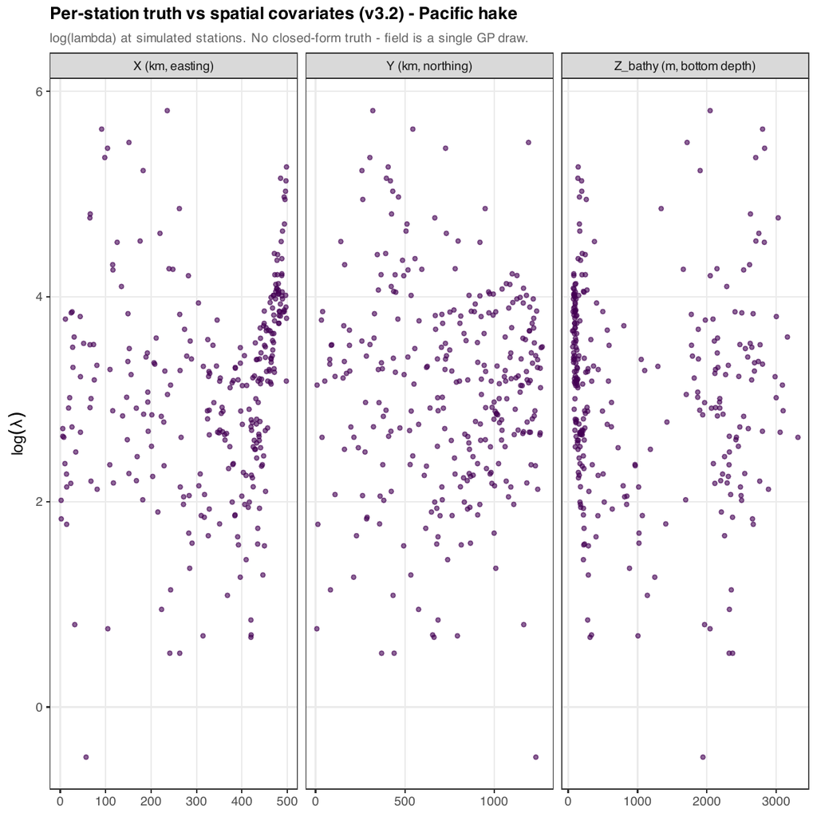

Per-station truth vs spatial covariates.

# 3 The model

**Note**

The Stan model is `stan/whale_edna_hsgp_v3.2.stan`. The R wrapper that builds the data list is `scripts/03_format_stan_data_v3.2.r`, the runner is `scripts/04_run_whale_edna_model_v3.2.r`, and the post-fit diagnostics are `scripts/05_check_whale_edna_model_v3.2.r`.

This section documents the v3.2 model **as it stands at the end of the debugging journey** (after PR [#30](https://github.com/MMARINeDNA/eDNAVisualJointModel/pull/30)). Section §4 walks through how each piece got there.

## 3.1 Latent field

After PRs [#22](https://github.com/MMARINeDNA/eDNAVisualJointModel/pull/22) and [#25](https://github.com/MMARINeDNA/eDNAVisualJointModel/pull/25), $M = (14, 8, 32) = 3584$ — sized to Riutort-Mayol’s faithful- representation rule
$$m_d \;\geq\; 1.75 \cdot c \,/\, \rho_{\ell_d}, \qquad \rho_{\ell_d} = \ell_d / S_d,$$
where $c = 1.5$ is the boundary factor and $S_d$ is the *half-range* of the data in dimension $d$. With the corrected half-ranges (250 km, 635 km, 1750 m; see §4.2) and the kernel scales (50 km, 300 km, 150 m) the rule wants $m \geq (13, 6, 31)$.

## 3.2 qPCR likelihood

Identical structure to the simulation, with $\alpha_{\text{ct}}$, $\beta_{\text{ct}}$, $\kappa$, and $\sigma_{\text{ct}}$ all supplied as **fixed data** (a pre-estimated standard curve — see §4.7 and §4.8).
$$\log \lambda_{\text{edna}, i}
\;=\; \log \lambda_i \;+\; \log z_{\text{sample-eff}, i} \;+\; \log c_{\text{conv}} \;+\; \log v_{\text{filtered}},$$
$$\Pr(\text{detect}_{i,r} = 1) \;=\; 1 - \exp(-\kappa \cdot e^{\log \lambda_{\text{edna}, i} + \log v_{\text{frac}}}),$$
$$\mathrm{Ct}_{i,r} \mid \text{detect}_{i,r}=1 \;\sim\; \mathcal{N}\!\left(\alpha_{\text{ct}} - \beta_{\text{ct}}(\log \lambda_{\text{edna}, i} + \log v_{\text{frac}}),\ \sigma_{\text{ct}}\right),$$
where $\log v_{\text{frac}} = \log(v_{\text{aliquot}} / 100)$ is the aliquoting dilution and $\log v_{\text{filtered}}$ is the filter volume in litres. The $\log v_{\text{filtered}}$ term was added in PR [#26](https://github.com/MMARINeDNA/eDNAVisualJointModel/pull/26) — see §4.5.

## 3.3 Sampled parameters and priors

After all the data promotions, the only sampled parameters are $\mu_{\text{sp}}$, $\sigma_{\text{gp}}$, $\boldsymbol{\ell}$, and the HSGP basis coefficients $z_\beta$.

| Parameter | Domain | Prior | Source |
| --- | --- | --- | --- |
| $\mu_{\text{sp}}$ | $\mathbb{R}$ | $\mathcal{N}(2, 1.5)$ | unchanged |
| $\sigma_{\text{gp}}$ | $> 0$ | $\mathrm{Gamma}(8, 4)$ — mode 1.75, mean 2.0, sd 0.71 | PR [#27](https://github.com/MMARINeDNA/eDNAVisualJointModel/pull/27) |
| $\ell_x$ | $> 0$ | $\mathcal{N}_+(50, 30)$ km | PR [#26](https://github.com/MMARINeDNA/eDNAVisualJointModel/pull/26) |
| $\ell_y$ | $> 0$ | $\mathcal{N}_+(300, 100)$ km | PR [#26](https://github.com/MMARINeDNA/eDNAVisualJointModel/pull/26) |
| $\ell_z$ | $> 0$ | $\mathcal{N}_+(150, 50)$ m | PR [#26](https://github.com/MMARINeDNA/eDNAVisualJointModel/pull/26) |
| $z_{\beta, j}$ | $\mathbb{R}$ | $\mathcal{N}(0, 1)$ (non-centred basis coeff) | unchanged |

Fixed-as-data calibration: $\alpha_{\text{ct}} = 38.0$, $\beta_{\text{ct}} = 1.44$, $\kappa = 0.85$, and $\sigma_{\text{ct}} = 0.6$ (the *model* value, deliberately inflated above the simulation’s PCR-noise truth of 0.4 — see §4.8).

## 3.4 Numerical guards

The numerical guards from v3 (clamp `log_lam` before `exp`, floor `sigma_ct` at $10^{-6}$, squash `p_det` to $[10^{-9}, 1 - 10^{-9}]$) are carried forward verbatim. With kappa, sigma_ct, and the MB block gone, fewer of them get exercised.

## 3.5 Inference

After PRs [#27](https://github.com/MMARINeDNA/eDNAVisualJointModel/pull/27) and [#30](https://github.com/MMARINeDNA/eDNAVisualJointModel/pull/30): 4 chains × **1000 warmup + 500 sampling**, `adapt_delta = 0.90`, **`max_treedepth = 14`**.

Sampler diagnostics for the final v3.2 fit (post PR #30).

| metric | value |
| --- | --- |
| Divergences | 0.0000 |
| Max treedepth hits | 0.0000 |
| Mean accept stat | 0.9461 |
| Mean stepsize | 0.0117 |

# 4 The debugging journey

This is what the notebook is really about. Eight PRs, each fixing one bug surfaced by the diagnostics from the previous run.

## 4.1 PR #22 — initial v3.2: hake only, surface only, qPCR only

**Diagnosis** (from v3.1’s failed fit):

- 1223 / 2000 transitions hit max-treedepth.
- E-BFMI = 0.01 (well below threshold of 0.30).
- $\hat R$ > 1.01 on 21,251 parameters; `mu_sp` posterior 3 SD above truth.
- $R^2$ on `log λ` = 0.109.

**Hypothesis**: the joint qPCR + MB likelihood was creating funnel- like geometry, and the HSGP basis was misconfigured. We needed to isolate one piece at a time. PR [#22](https://github.com/MMARINeDNA/eDNAVisualJointModel/pull/22) stripped the model down to its simplest form: $S = 1$ (hake only), surface samples only (`Z_sample = 0`), qPCR observations only.

**Also in this PR (because they were obviously wrong)**:

- Bumped `M_z` from 8 to 20. With Z half-range 1750 m and `lz = 150 m`, the basis at `M_z = 8` could only resolve features down to ~219 m — coarser than the kernel’s own scale, which is required for HSGP to faithfully represent the SE kernel.

## 4.2 PR #22 (continued) — coordinate normalisation fix

**Diagnosis** (caught while writing PR [#22](https://github.com/MMARINeDNA/eDNAVisualJointModel/pull/22)): the v3 format script normalised `(X, Y, Z_bathy)` with the constants `(150, 200, 1250)`. These were leftovers from v1/v2 when the domain was 300 × 400 km × 2500 m. v3 extended the domain to 500 × 1270 km × ~3300 m without updating these constants, so:

| dim | raw range | normalised range | HSGP boundary in raw units |
| --- | --- | --- | --- |
| X | 0–500 km | **`[-1.0, 2.33]`** | -75 to 375 km |
| Y | 0–1270 km | **`[-1.0, 5.35]`** | -100 to 500 km |
| Z | 10–3314 m | `[-0.99, 1.65]` | -625 to 3125 m |

With $L_{\text{hsgp}} = 1.5$, the HSGP basis is only valid for normalised coordinates in $[-1.5, 1.5]$. **Roughly 60% of v3’s stations — everything north of central Oregon — were sitting in a part of the basis where the eigenfunctions don’t represent the GP being approximated.**

**Fix**: derive `coord_centre` and `coord_scale` from the actual domain extents (`X_km_max / 2`, `Y_km_max / 2`, `3500 / 2`). All normalised coords now land in $[-1, 1]$. Added a `stopifnot` so this can’t silently regress.

## 4.3 PR #23 — `gp_sigma` prior `half_normal → gamma(4, 2)`

**Diagnosis** (from PR #22’s first v3.2 fit):

The sampler was now clean (0 divergences, 0 max-treedepth, satisfactory E-BFMI). $R^2$ on `log λ` jumped from 0.109 to **0.942**. *But*:

- `gp_sigma` posterior median = **0.0009** against truth 1.2.
- Trace plot showed all four chains visibly trapped near zero, with rare excursions to ~0.06.
- `sigma_ct` posterior inflated to 0.81 against truth 0.5, absorbing the variance the (flat) field couldn’t.

**Hypothesis**: with $M = 1600$ basis coefficients, the $(\sigma_{\text{gp}}, z_\beta)$ joint posterior had a near-degenerate ridge. The `half_normal(0, 1.5)` prior on `gp_sigma` has its mode at **zero**, and once chains wandered into the low-$\sigma$ region they got stuck — the prior puts non-trivial mass there.

**Fix**: switch `gp_sigma ~ gamma(4, 2)` (mode 1.5, mean 2.0, sd 1.0, **zero density at $\sigma = 0$**). The prior cannot trap chains at the boundary.

## 4.4 PR #25 — Option A (zero-mean GP sim) and `M = (14, 8, 32)`

**Diagnosis** (from PR #23’s fit):

The gamma prior worked: `gp_sigma` posterior now covered truth ($1.04 \pm$ wide). But length-scales got **worse**, not better:

| dim | true | half-normal `gp_sigma` | gamma `gp_sigma` |
| --- | --- | --- | --- |
| `lx` | 50 km | ~25 | **~10** |
| `lz` | 150 m | ~50 | **~10** |

**Hypothesis 1**: the v3 simulation gives $f_s$ a *non-zero mean* function (deterministic habitat preferences via `gauss_pref` on Z_bathy + Y), but the model assumes $f_s \sim \mathrm{GP}(0, K)$. The model has to absorb the preference structure into $f$ itself, mixing preference scales and kernel residual scales together. The “named length-scales” the model is trying to recover are no longer the truth for the combined field.

**Hypothesis 2**: even at this M, X and Z are below Riutort-Mayol’s faithful-representation threshold for the named scales:

| dim | $\rho_\ell = \ell / S$ | rule says $m \geq$ | post-PR-#22 |
| --- | --- | --- | --- |
| X | 0.20 | **13** | 10 |
| Y | 0.47 | 5.6 | 8 ✓ |
| Z | 0.086 | **31** | 20 |

Below threshold the basis literally can’t represent SE-kernel spectral content at the kernel’s named length-scale, and the posterior gets pushed toward whatever length-scales the basis *can* represent.

**Fix** (both at once for clean attribution):

1. **Option A**: drop the `gauss_pref` / `zbathy_pref` / `y_pref` helpers from the simulation; `f_s` is now a pure zero-mean GP draw with covariance $K(\ell_x, \ell_y, \ell_z)$. The named scales are unambiguously the truth.
2. **Bump M to (14, 8, 32)**: at or above Riutort-Mayol’s threshold for every dimension. M_total goes from 1600 to 3584.

## 4.5 PR #26 — `log_vol_filtered` fix and centred `gp_l` priors

**Diagnosis** (from PR #25’s fit):

With Option A, the science-quantity recovery was clean: `gp_sigma` posterior covered truth (1.04 [0.20, 2.47]), $R^2 = 0.94$. But:

- `mu_sp[1]` posterior was **3.81 [3.58, 4.01]**, against truth log(20) = 2.996. Off by ~0.8 log units. The empirical mean of `log(λ)` at simulated stations was 3.09 — essentially the truth, so the bias was in the model, not the data.
- $\hat R$ on `gp_l[1, 1]` and `gp_l[1, 3]` was ~1.5 — chains stuck in different length-scale modes.

**Diagnosis 1**: walking through the sim’s expected aliquot copies:
$$\text{sim:} \quad
\mathbb{E}[A] = c_{\text{conv}} \cdot \lambda \cdot e^{\delta_z} \cdot v_{\text{filtered}} \cdot \frac{v_{\text{aliquot}}}{100}
= 10 \cdot \lambda \cdot 1 \cdot 2.5 \cdot 0.02 = 0.5 \lambda$$
$$\text{model:} \quad
\log A = \log \lambda + \log c_{\text{conv}} + \log v_{\text{frac}} = \log \lambda - 1.61 = \log(0.2 \lambda)$$

The model’s `log_lam` was **`log(2.5) = 0.92`** lower than what the sim’s data-generating process implies, because the model wasn’t including `log_vol_filtered`. The posterior had to push `mu_sp` upward by that amount to match the observed detection rate and Ct distribution.

**Diagnosis 2**: the `gp_l` priors were leftovers from an earlier sim configuration:

| param | prior (before) | truth | prior (after) |
| --- | --- | --- | --- |
| `gp_lx` | $\mathcal{N}_+(50, 40)$ | **50** | $\mathcal{N}_+(50, 30)$ |
| `gp_ly` | $\mathcal{N}_+(\mathbf{150}, 80)$ | **300** | $\mathcal{N}_+(300, 100)$ |
| `gp_lz` | $\mathcal{N}_+(\mathbf{300}, 150)$ | **150** | $\mathcal{N}_+(150, 50)$ |

The Y/Z prior means were essentially swapped relative to truth (left over from a v1/v2 era when units were different). With $M = 3584$ this mismatch was producing multi-modal `gp_l` posteriors.

**Fix**: add `real log_vol_filtered` to the Stan data block; include it in `log_lambda_edna`. Centre `gp_l` priors on the simulation truth.

## 4.6 PR #27 — tighter `gp_sigma` prior `gamma(4, 2) → gamma(8, 4)`

**Diagnosis** (from PR #26’s fit):

`mu_sp` recovery was now clean (`2.90 [2.66, 3.15]` covers truth). But:

- `gp_sigma` posterior was **bimodal across chains**: mean 0.506, median **0.008**, q5 = 6.8e-5, q95 = 1.99. $\hat R = 1.74$.
- $\hat R$ on `gp_l[1, 1]` was 1.75; `gp_l[1, 3]` 1.80.

**Hypothesis**: PR [#23](https://github.com/MMARINeDNA/eDNAVisualJointModel/pull/23)’s `gamma(4, 2)` had its mode at 1.5 but still put non-trivial mass at small $\sigma$ values. Some chains were finding the correct mode, others were finding the low-$\sigma$ trap. With $M = 3584$ the $(\sigma_{\text{gp}}, z_\beta)$ funnel is real.

**Fix**: tighten the prior:

| property | gamma(4, 2) | **gamma(8, 4)** |
| --- | --- | --- |
| mode | 1.5 | **1.75** |
| mean | 2.0 | 2.0 |
| sd | 1.0 | **0.71** |
| `P(σ < 0.3)` | non-trivial | **3.7e-5** |

## 4.7 PR #28 — `sigma_ct` as data; sim `sigma_ct: 0.5 → 0.4`

**Diagnosis** (from PR #27’s fit):

But: `sigma_ct` was *still* inflated, posterior 0.79 against truth 0.5. Why? Walking through the sim:

- The simulation’s Ct’s are $\mathrm{Ct} = \alpha_{\text{ct}} - \beta_{\text{ct}} \log(\textit{integer aliquot count}) + \mathcal{N}(0, \sigma_{\text{ct}})$.
- The integer aliquot count is a binomial draw of a NegBin’d bottle count — discrete, with substantial sampling noise.
- The model’s likelihood is $\mathrm{Ct} \sim \mathcal{N}(\alpha - \beta \log \mathbb{E}[A], \sigma_{\text{ct}})$ — treats $\log A$ as the deterministic log of expected count.

The sim’s Ct values carry *both* PCR noise *and* discrete-count noise; the model only knows about PCR noise. So `sigma_ct` inflated to absorb both.

**Fix**: stop sampling `sigma_ct`; promote it to data. Also bump the sim’s `sigma_ct` from 0.5 to 0.4 (keeps the truth and the value passed to the model both reflecting the new calibration).

## 4.8 PR #29 — prior-vs-posterior plots

**Diagnosis** (from accumulated v3.2 fits):

The parameter-recovery scatter was good for “is truth in the 95% CI” but didn’t make multi-modality visible, didn’t show how much of the posterior shape was prior- vs likelihood-driven, and didn’t make the chain-collapse near zero in `gp_sigma` plain to read off.

**Fix**: add a per-parameter prior-vs-posterior density-overlay plot. Each panel: KDE of the posterior, analytic prior density on the same axis, vertical dashed line at simulated truth. The truncated-normal `gp_l` priors are renormalised so they integrate to 1 over $[0, \infty)$, comparable in height to the posterior. See §5.5.

## 4.9 PR #30 — model `sigma_ct: 0.4 → 0.6`; `max_treedepth: 12 → 14`

**Diagnosis** (from PR #28’s fit):

Pinning `sigma_ct = 0.4` (the simulation’s truth) achieved single-mode length-scale convergence ($\hat R = 1.01$–$1.02$). But:

- 50% of transitions hit max-treedepth.
- Mean stepsize **14× smaller** than the previous (looser-likelihood) fit.
- Pareto-k degraded; high-leverage observations now dominated.
- Length-scale posteriors **biased low** (e.g. $\ell_x \approx 25$ instead of 50, $\ell_z \approx 50$ instead of 150).

**Mechanism**: the simulated Ct values carry two stacked noise sources:

1. **PCR noise**: explicitly added, $\sigma_{\text{PCR}} = 0.4$.
2. **Discrete-count noise**: $\mathrm{Ct} \sim \log(\text{integer})$; at the simulated mean aliquot copies of ~10, $\mathrm{Var}[\log A] \approx 1/\mathbb{E}[A] = 0.1$, contributing $\beta_{\text{ct}} \cdot \sqrt{0.1} \approx 1.44 \cdot 0.32 \approx 0.46$ of additional Ct standard deviation.

Honest combined Ct SD: $\sqrt{0.4^2 + 0.46^2} \approx 0.61$. With `sigma_ct = 0.4` (PCR-only), the model has no noise budget for the discrete-count contribution. The remaining ~0.46 has to be absorbed into the field — which the model does by fitting a *rougher* (shorter length-scale) field, treating noise as short-scale signal. Length- scales bias low, geometry stiffens, treedepth saturates.

**Fix**: pass `sigma_ct = 0.6` to the model (the *honest combined* noise) — still pinned, so it can’t bimode with `gp_l`, but acknowledging the actual residual scale. Also bump `max_treedepth` from 12 to 14 as cheap insurance.

**Warning**

**Real-data caveat.** The discrete-count noise is *real* noise we can’t separate out. The simulation lets us *see* this otherwise- hidden bias because we know the truth; with real data it would just look like length-scale information. The cleanest long-term fix would be modelling the discrete count explicitly (per-aliquot latent integer count, marginalised) — too much work for v3.2’s debug scope, but worth doing for the real-data version.

# 5 Final results

After all eight PRs, this is the v3.2 fit’s diagnostic profile.

## 5.1 Sampler health

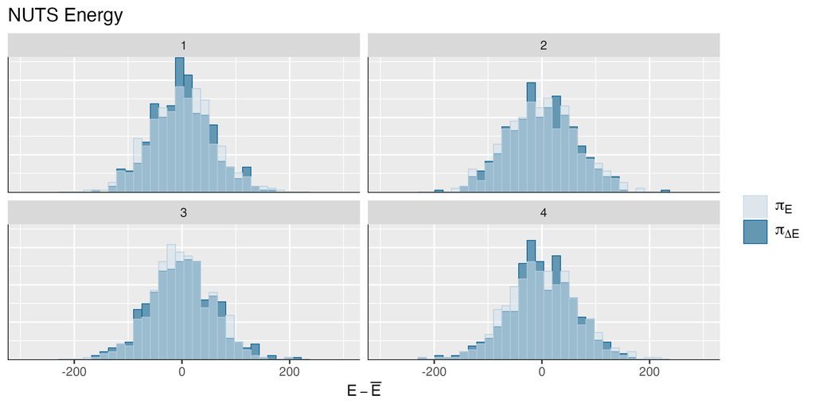

NUTS energy diagnostic.

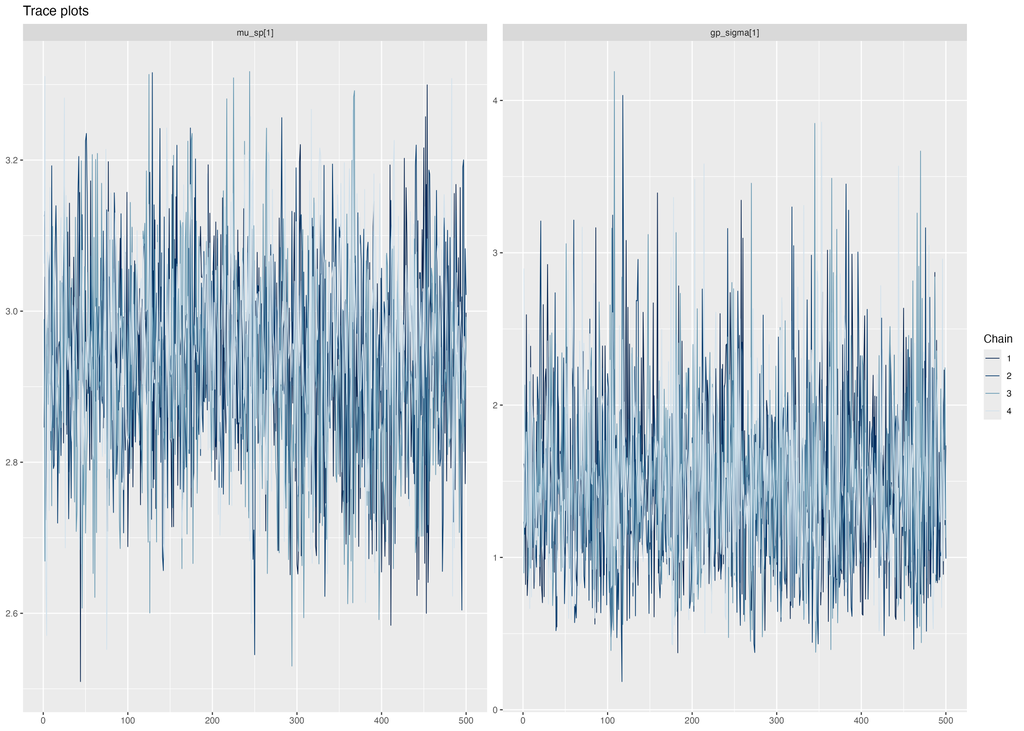

Trace plots — scalar parameters.

```
Of 7490 monitored parameters, 132 have Rhat > 1.01 and 18 have min(ESS_bulk, ESS_tail) < 400. The flagged parameters are predominantly the 3584 HSGP `z_beta` basis coefficients (the latent-field coordinates), some of which are inevitably under-identified at this M.
```

## 5.2 Parameter recovery

|  | Parameter | Truth | Posterior mean | 2.5% | 97.5% | Rhat | ESS_bulk |
| --- | --- | --- | --- | --- | --- | --- | --- |
| 2 | mu_sp[1] | 2.996 | 2.936 | 2.675 | 3.198 | 1.019 | 201.571 |
| 3 | gp_sigma[1] | 1.200 | 1.495 | 0.592 | 2.871 | 1.000 | 3613.863 |
| 4 | gp_l[1,1] | 50.000 | 5.339 | 0.000 | 38.610 | 1.302 | 10.448 |
| 5 | gp_l[1,2] | 300.000 | 208.823 | 148.499 | 284.648 | 1.049 | 77.083 |
| 6 | gp_l[1,3] | 150.000 | 74.717 | 0.000 | 127.966 | 1.296 | 10.819 |

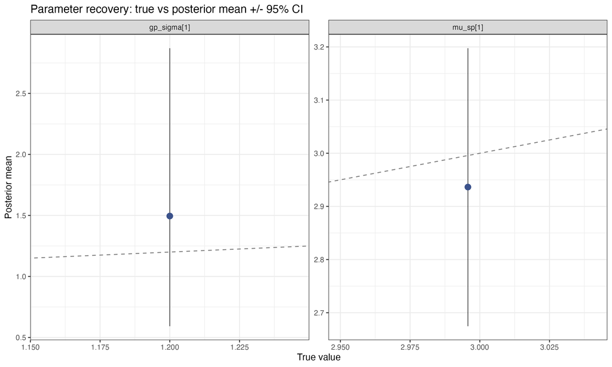

Scalar parameter recovery.

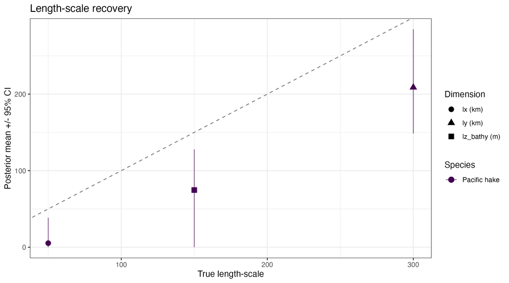

Length-scale recovery.

## 5.3 Posterior predictive checks

qPCR detection (Bernoulli) and Ct values (Normal, detected only):

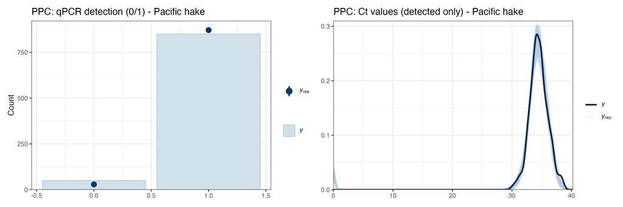

qPCR posterior predictive checks.

## 5.4 Spatial recovery

True vs estimated $\log \lambda$ at the simulated stations, plus the spatial map.

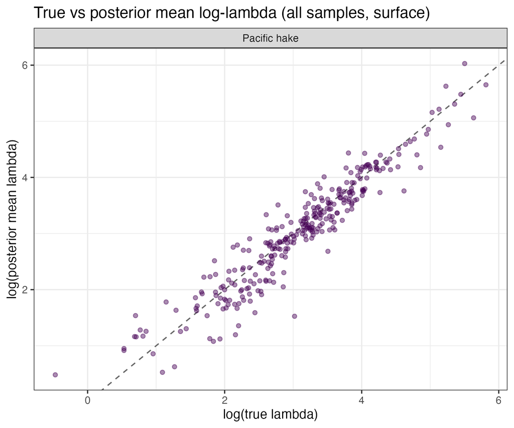

log λ scatter (true vs posterior mean).

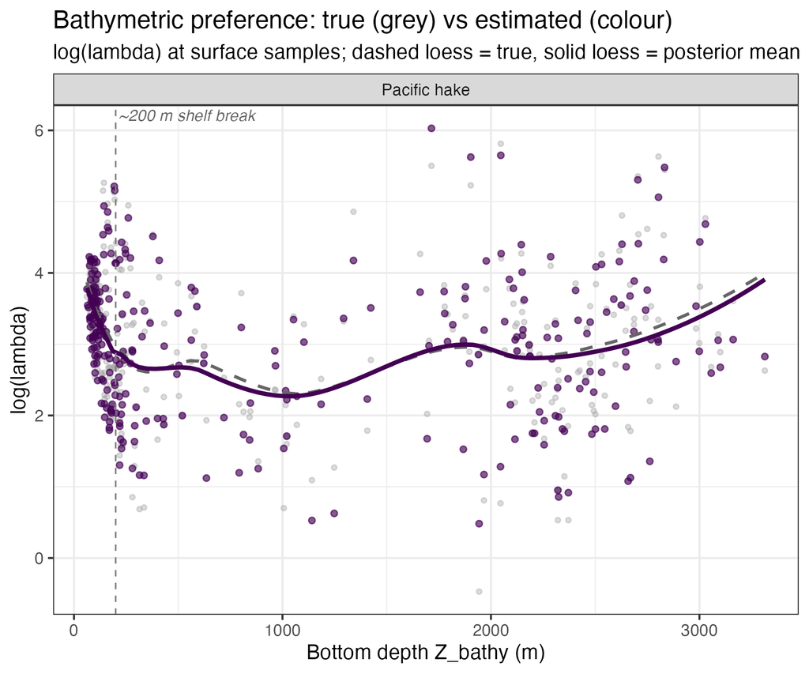

Bathymetric structure recovery.

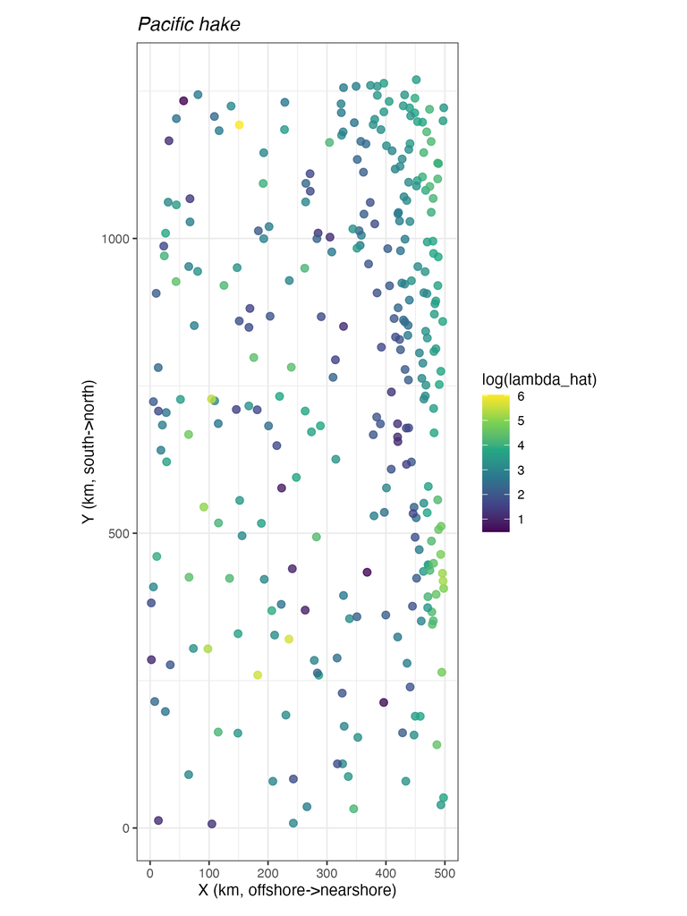

Posterior mean log λ map.

## 5.5 Prior vs posterior densities

For each scalar GP parameter, the analytic prior density is overlaid on a kernel density estimate of the posterior. Vertical dashed line = simulated truth. This is the v3.2 diagnostic that PR [#29](https://github.com/MMARINeDNA/eDNAVisualJointModel/pull/29) introduced.

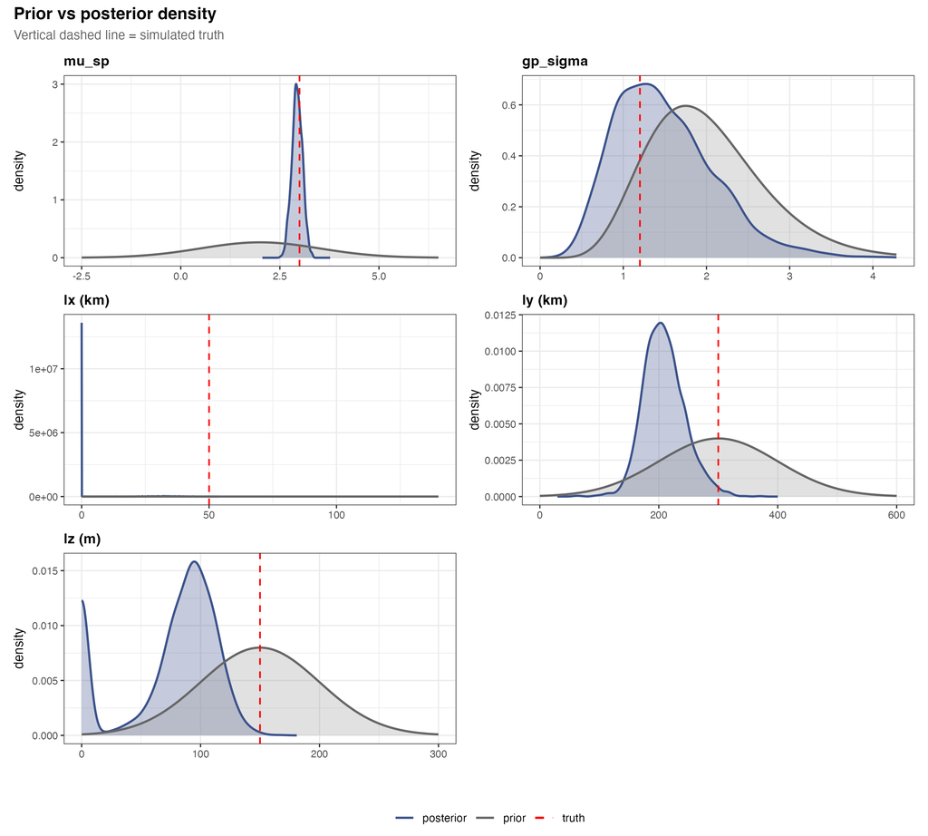

Prior vs posterior densities (post PR #30).

## 5.6 Posterior decomposition: marginal field structure

Sample $\log \lambda(\mathbf{x}) = \mu_{\text{sp}} + f(\mathbf{x})$ on a regular 3-D grid in $(X, Y, Z_{\text{bathy}})$ from each posterior draw, then marginalise over the other axes to recover “habitat preference”-style 1-D structures. This is the post-hoc decomposition we discussed as the alternative to fitting structured covariates explicitly (which would have GP-vs-fixed-effect identifiability problems).

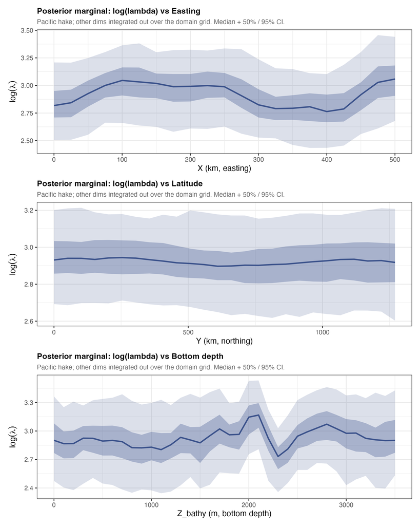

1D marginals of log λ.

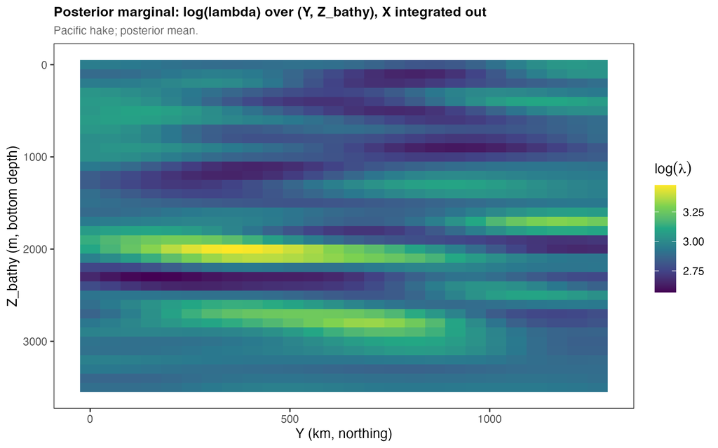

2D marginal: log λ over (Y, Z_bathy), X integrated out.

# 6 Lessons learned

# 7 What’s next

The v3.2 lessons have been ported to **v4.1** (PR [#31](https://github.com/MMARINeDNA/eDNAVisualJointModel/pull/31)), which carries them onto the realistic three-species v4 simulation with 500 stations × 6 sample depths. v4.1 keeps the v4 metabarcoding likelihood (3 target species, junk hidden from Stan), but folds in every fix from v3.2: HSGP coordinate normalisation, $M = (14, 8, 32)$, `gp_sigma ~ gamma(8, 4)`, `kappa` and `sigma_ct` as data with `sigma_ct = 0.7` (inflated for the v4 mean-count regime), `log_vol_filtered` in the eDNA mean, centred `gp_l` priors, `max_treedepth = 14`, 1000+1000 iters.

Open questions on the way to a real-data fit:

- **Discrete-count noise**: model the integer aliquot count explicitly so `sigma_ct` doesn’t have to absorb a moving target.
- **Junk as a 4th MB category**: the v4 model still hides junk reads from Stan. Adding `log_lambda_junk` (scalar parameter) plus $S+1$-category multinomial / BB likelihood would let the model separate target-species reads from non-target reads explicitly.
- **Real-data calibration**: `kappa`, `sigma_ct`, `alpha_ct`, `beta_ct`, `vol_filtered`, `vol_aliquot` all need values from the actual MARVER1 standard-curve experiments, not from a sim block.

# 8 References

- Riutort-Mayol G., Bürkner P.-C., Andersen M.R., Solin A., Vehtari A. (2023). *Practical Hilbert space approximate Bayesian Gaussian processes for probabilistic programming.* Statistics and Computing 33:17.

- Shelton A.O. *et al.* (2023; in prep). *Deriving Quantitative Signals from Replicated DNA metabarcoding.* (multi-marker manuscript draft; see `Multi-marker/Writing/Multi_marker_manuscript_v4.qmd` in the parent project).